# Cohomology in Representation Theory

# 13 Tuesday, March 01

Recall the definition of the localization of an $R\in \mathsf{CRing}^{\operatorname{unital}}$ at a submonoid $S \leq (M, \cdot)$, written $R \left[ { \scriptstyle { {S}^{-1}} } \right]$. Similarly for $M\in {\mathsf{R}{\hbox{-}}\mathsf{Mod}}$, one can form $M \left[ { \scriptstyle { {S}^{-1}} } \right]$, and $({-}) \left[ { \scriptstyle { {S}^{-1}} } \right]$ is a functor where the induced map on $M \xrightarrow{f} N$ is $f_S(m/s) \mathrel{\vcenter{:}}= f(m)/s$.

For $I\in \operatorname{Id}(R)$, let $j(I) \mathrel{\vcenter{:}}=\left\{{a\in R{~\mathrel{\Big\vert}~}a/s\in I \text{ for some } s\in S}\right\}$ which is again an ideal in $R$. Then

1. $j(I)_S = I$,
2. $I_S = R_S \iff I$ contains an element of $S$.

$\impliedby$: $I_S \subseteq R_S$ is clear. Let $x/t\in R_S$ and $s\in I \cap S$, then ${sx\over st} = {x\over t}\in I_S$.

$\implies$: Write $1=i/s$ to produce $t\in s$ with $t(s-i) = 0$. Then $z=ts \in S$ and $z=it\in I$ so $z \in I \cap S$.

Let $P\in \operatorname{Spec}R$ with $S \cap p = \emptyset$, then $j(P_S) = P$.

$\supseteq$: Clear.

$\subseteq$: Let $a\in j(P_S)$, so $a/s=p/t$ for $s,t\in S, p\in P$ and $\exists u\in S$ such that $u(at-sp)=0\in P$, so $uat - usp\in P$ where $usp\in P$. Thus $uat\in P \implies a(ut)\in P\implies a\in P$, since $ut\in S$ and $ut\not\in P$.

There is an order-preserving correspondence
$$\begin{align*}
\left\{{p\in \operatorname{Spec}R {~\mathrel{\Big\vert}~}p \cap S = \emptyset}\right\} &\rightleftharpoons\operatorname{Spec}R \left[ { \scriptstyle { {S}^{-1}} } \right] \\
P &\mapsto P \left[ { \scriptstyle { {S}^{-1}} } \right] \\
j(P') &\mapsfrom P'
.\end{align*}$$

We need to show

1. $P \left[ { \scriptstyle { {S}^{-1}} } \right] \in \operatorname{Spec}R \left[ { \scriptstyle { {S}^{-1}} } \right]$ is actually prime.
2. If $P'\in \operatorname{Spec}R \left[ { \scriptstyle { {S}^{-1}} } \right]$ then $j(P')\in \operatorname{Spec}R$ with $j(P') \cap S = \emptyset$.

For one:
$$\begin{align*}
{x\over t}, {y\over t} \in P_S
&\implies {xy\over st} \in P_S \\
&\implies xy \in j(P_S) = P \\
&\implies x\in P \text{ or } y\in P \\
&\implies x/s\in P \text{ or } y/s\in P
.\end{align*}$$

For two:
$$\begin{align*}
xy\in j(P')
&\implies {xy\over s}\in P' \\
&\implies {x\over 1}{y\over s}\in P' \\
&\implies {x\over 1}\in P' \text{ or } {y\over s}\in P' \\
&\implies {x}\in P' \text{ or } {y}\in P' \\
.\end{align*}$$

If $x\in j(P') \cap S$ then ${x\over t}\in P'$ so ${t\over x}{x\over t}\in P'$. $\contradiction$

One can then check that these two maps compose to the identity.

Show that if $p\in \operatorname{Spec}R$ then $R_p \in \mathsf{Loc}\mathsf{Ring}$ is local. Use that the image of $p$ in $R_p$ is $P_p = R_p\setminus R_p^{\times}$, making it maximal and unique.

Show that

1. $M=0 \iff M_S = 0$ for all $S$,
2. $M=0 \iff M_p = 0\, \forall p\in \operatorname{mSpec}R$,
3. $M=0 \iff M_p = 0\, \forall p\in \operatorname{Spec}R$, noting that this is a stronger condition than maximal.

For (2), use that $\operatorname{Ann}_R(x)$ is a proper ideal and thus contained in a maximal, and show by contradiction that $x/1\neq 0\in M_p$.

Show that if $f\in {\mathsf{R}{\hbox{-}}\mathsf{Mod}}(M, N)$ then

- $f$ injective (resp. surjective) $\implies f_S$ injective (resp. surjective)
- If $f_p$ is injective for all $p\in \operatorname{Spec}R$, then $f$ is injective (resp. surjective)
- If $M$ is flat then $M_S$ is flat
- If $M_p$ is flat for all $p$ then $M$ is flat.

Recall that for $A \subseteq R$, $V(A) \mathrel{\vcenter{:}}=\left\{{p\in \operatorname{Spec}R{~\mathrel{\Big\vert}~}p\supseteq A}\right\}$. Letting $I(A)$ be the ideal generated by $A$, then check that $V(I(A)) = V(A)$ and $V(I) = V(\sqrt I)$.

Check that defining closed sets as $\left\{{V(A) {~\mathrel{\Big\vert}~}A \subseteq R}\right\}$ forms the basis for a topology on $\operatorname{Spec}R$, and $V(p) \cap V(q) = V(pq)$.

Next time: generic points, idempotents, irreducible sets.

# 14 Tuesday, March 15

> See https://www.math.ucla.edu/~balmer/Pubfile/TTG.pdf

Recall that $V(B) \mathrel{\vcenter{:}}=\left\{{p\in \operatorname{Spec}R {~\mathrel{\Big\vert}~}p\supseteq B}\right\}$ are the closed sets for the Zariski topology, and $V(B) = V(\left\langle{B}\right\rangle)$. Write $I(A) = \displaystyle\bigcap_{p\in A} p$ for the vanishing ideal of $A$, and note $V(I(A)) = { \operatorname{cl}} _{\operatorname{Spec}R} A$. Recall $\sqrt{J} = \displaystyle\bigcap_{p\supseteq J} = \left\{{x\in R {~\mathrel{\Big\vert}~}\exists n\, \text{ such that } x^n \in J}\right\}$, so $\sqrt{0}$ is the nilradical, i.e. all nilpotent elements. An ideal $J$ is radical iff $\sqrt J = J$.

For $X=\operatorname{Spec}R$, $I(V(J)) = \sqrt{J}$, and there is a bijection between closed subsets of $X$ and radical ideals in $R$.

$$\begin{align*}
I(V(J)) = \displaystyle\bigcap_{p\in V(J)} p = \displaystyle\bigcap_{p\supseteq J} p = \sqrt{J}
,\end{align*}
and
\begin{align*}
J \xrightarrow{V} V(J) \xrightarrow{I} I(V(J)) = \sqrt{J} = J
.\end{align*}$$

Recall that $X$ is **reducible** iff $X= X_1 \cup X_2$ with $X_i$ nonempty proper and closed.

For $R\in \mathsf{CRing}$, a closed subset $A \subseteq X$ is irreducible iff $I(A)$ is a prime ideal.

$\implies$: Suppose $A$ is irreducible, let $fg\in I(A) = \displaystyle\bigcap_{p\in A} p$. Then $fg\in p\implies f\in [$ without loss of generality for all $p\in A$, and $A = (A \cap V(f)) \cup(A \cap V(g))$ so $A \subseteq V(f)$ or $A \subseteq V(g)$. Thus $f\in \sqrt{\left\langle{f}\right\rangle} = I(V(f)) \subseteq I(A)$ (similarly for $g$).

$\impliedby$: Suppose $I(A)$ is a prime ideal and $A = A_1 \cup A_2$ with $A_j$ closed, so $I(A) \subseteq I(A_j)$. Then
$$\begin{align*}
I(A) = I(A_1 \cup A_2) = I(A_1) \cap I(A_2)
.\end{align*}
If \(I(A_j) \subsetneq I(A)\) are proper containments, then one reaches a contradiction: if \(x\in I(A_1)\) and \(y\in I(A_2)\), use that \(xy\in I(A)\) to conclude \(x\in I(A)\) or \(y\in I(A)\).$$

Let $X\in {\mathsf{Top}}$; TFAE:

1. $X$ is irreducible.
2. Any two open nonempty sets intersect.
3. Any nonempty open is dense in $X$.
1. Any irreducible subset of $X$ is entirely contained in a single irreducible component.
2. Any space is a union of its irreducible components.
- A space is Noetherian iff any descending chain of closed sets stabilizes, and if $R$ is a Noetherian ring then $X=\operatorname{Spec}R$ is a Noetherian space. Note that the converse may not hold in general!
- A Noetherian space has a unique decomposition into irreducibles.
- Any irreducible component is the closure of a point.
- Any nonempty irreducible closed subset $A \subseteq \operatorname{Spec}R$ contains a unique generic point $p = I(A)$.

Coming up:

- Group cohomology, the Hopf algebra structure on $kG$
- Cohomology using minimal resolutions
- $R = H^0(G; k) = \operatorname{Ext} _{kG}^0(k, k)$ which is a Noetherian ring
- Use minimal resolutions to define $c_{kG}(M)$, the rate of growth of a minimal projective resolution of $M$ (1977)
- Support varieties: $R\mathrel{\vcenter{:}}=\operatorname{Ext} ^i_{kG}(k,k)\curvearrowright\tilde M\mathrel{\vcenter{:}}=\operatorname{Ext} ^0_{kG}(M, M)$, let $J = \operatorname{Ann}_R(\tilde M)$ and $V_G(M) = \operatorname{Spec}(R/J)$.
- An equality of numerical invariants: $c_{kG}(M) = \dim V_G(M)$.
- Paul Balmer’s tensor triangular geometry.

# 15 Tuesday, March 22

## 15.1 Hilbert-Serre

Setup: $V\in {\mathsf{gr}\,}_{\mathbb{Z}}{\mathsf{k}{\hbox{-}}\mathsf{Mod}}$ a graded vector space, so $V = \bigoplus _{r\geq 0} V_r$ with $\dim_k V_r < \infty$. Define the **Poincare series**
$$\begin{align*}
p(V, t) = \sum_{r\geq 0} \dim V_r t^r
.\end{align*}$$

Let $R\in {\mathsf{gr}\,}_{\mathbb{Z}}\mathsf{CRing}$ be of finite type over $A_0$ for $A\in {{k}{\hbox{-}}\mathsf{Alg}}$ and suppose $R$ is finitely generated over $A_0$ by homogeneous elements of degrees $k_1,\cdots, k_s$. Supposing $V\in {\mathsf{A}{\hbox{-}}\mathsf{Mod}}^{\mathrm{fg}}$,
$$\begin{align*}
p(V, t) = {f(t) \over \prod_{1\leq j\leq s} 1-t^{k_j} }, \qquad f(t) \in {\mathbb{Z}}[t]
.\end{align*}$$

Suppose that
$$\begin{align*}
p(V, t) = {f(t) \over \prod_{1\leq j\leq s} 1-t^{k_j} } = \sum_{r\geq 0} a_r t^r, \qquad f(t) \in {\mathbb{Z}}[t], a_r\in {\mathbb{Z}}_{\geq 0}
.\end{align*}
Let \(\gamma\) be the order of the pole of \(p(t)\) at \(t=1\). Then$$

1. There exists $K > 0$ such that $a_n \leq K n^{\gamma-1}$ for $n\geq 0$
2. There does *not* exist $k > 0$ such that $a_n \leq k n^{\gamma - 2}$.

Let $V$ be a graded vector space of finite type over $k$. The **rate of growth** $\gamma(V)$ of $V$ is the smallest $\gamma$ such that $\dim V_n \leq C n^{\gamma-1}$ for all $n\geq 0$ for some constant $C$.

Compare this to the complexity $C_G(M) = \gamma(P_0)$ where $P^0 \rightrightarrows M$ is a minimal projective resolution.

## 15.2 Finite Generation of Cohomology

Fix $G \in {\mathsf{Fin}}{\mathsf{Grp}}$. Recall that ${ {H}^{\scriptscriptstyle \bullet}} (G; k) { {\operatorname{Ext} }^{\scriptscriptstyle \bullet}} _{G}(k, k)$ has an algebra structure given by concatenation of LESs:

[figure not shown]

> Link to Diagram

Recall that $\operatorname{Ext} ^n_{G}(k, k) = \mathop{\mathrm{Hom}}_{kG}(P_n, k)$, providing the additive structure. Moreover, $\operatorname{Ext} _{kG}(M, M)$ is a ring, and if $N\in {\mathsf{kG}{\hbox{-}}\mathsf{Mod}}$, then $\operatorname{Ext} _{kG}{N, M} \in {\mathsf{\operatorname{Ext} _{kG}(M, M)}{\hbox{-}}\mathsf{Mod}}$. Similarly $\operatorname{Ext} ^0_{kG}(N, M) \in {\mathsf{ { {\operatorname{Ext} }^{\scriptscriptstyle \bullet}} (k, k)}{\hbox{-}}\mathsf{Mod}}$ by tensoring LESs.

There is a coproduct
$$\begin{align*}
kG &\xrightarrow{\Delta} kG \otimes_k kG \\
g &\mapsto g\otimes g
.\end{align*}
There is a cup product:$$

[figure not shown]

> Link to Diagram

It is a theorem that this coincides with the Yoneda product.

- $H^0(G, k)$ is a graded commutative ring, so $xy = (-1)^{{\left\lvert {x} \right\rvert} {\left\lvert {y} \right\rvert}} yx$
- The even part ${ {H}^{\scriptscriptstyle \bullet}} ^{\text{even}}(G; k)$ is a (usual) commutative ring.
- $H^0(G; k)$ is a finitely generated in ${\mathsf{Alg}_{/k} }$
- If $M\in {\mathsf{kG}{\hbox{-}}\mathsf{Mod}}$ then $\operatorname{Ext} ^0_{kG}(k, M) \in {\mathsf{ { {H}^{\scriptscriptstyle \bullet}} (G; k) }{\hbox{-}}\mathsf{Mod}}$.

Quillen described $\operatorname{mSpec} { {H}^{\scriptscriptstyle \bullet}} (G, k)^{ \text{red} }$ in the 70s. Idea: look at $E \hookrightarrow G$ the elementary abelian subgroups, so $E \cong C_p{ {}^{ \scriptscriptstyle\times^{m} } }$ where $p = \operatorname{ch}k$, and consider $V_G(k) = \displaystyle\bigcup_{E\leq G} V_E(k)/\sim$ the union of all elementary abelian subgroups, where $V_G(k) \mathrel{\vcenter{:}}=\operatorname{mSpec} { {H}^{\scriptscriptstyle \bullet}} ^{}(G; k)^{ \text{red} }$. Note that in characteristic zero, this is semisimple and only $H^0=k$ survives.

- For $A = C_p$ with $\operatorname{ch}k = p > 0$, then
  $$\begin{align*}
  R \mathrel{\vcenter{:}}= H^0(C_p; k) \cong
  \begin{cases}
  k[x,y]/\left\langle{y^2}\right\rangle, {\left\lvert {x} \right\rvert} = 2, {\left\lvert {y} \right\rvert} = 1 & p\geq 3
  \\
  k[x], {\left\lvert {x} \right\rvert} = 1 & p = 2.
  \end{cases}, \qquad \operatorname{mSpec}R \cong {\mathbb{A}}^1_{/ {k}}
  .\end{align*}$$
- Dan’s favorite: $A = u({\mathfrak{g}})$ for ${\mathfrak{g}}= {\mathfrak{sl}}_2$ with $\operatorname{ch}k = p \geq 3$ for $u$ the *small enveloping algebra*. Friedlander-Parshall show $\operatorname{mSpec}R = k[{\mathcal{N}}]$ for ${\mathcal{N}}\mathrel{\vcenter{:}}=\left\{{M { \begin{bmatrix} {a} & {b} \\ {c} & {-a} \end{bmatrix} } {~\mathrel{\Big\vert}~}M\text{ is nilpotent}}\right\}$. This can be presented as
  $$\begin{align*}
  k[{\mathcal{N}}] \cong k[x,y,z] / \left\langle{z^2 + xy}\right\rangle, {\left\lvert {x} \right\rvert}, {\left\lvert {y} \right\rvert}, {\left\lvert {z} \right\rvert} = 2
  ,\end{align*}
  and we’ll see how finite generation is used in this setting.$$

# 16 Tuesday, March 29

Setup: for $G \in {\mathsf{Fin}}{\mathsf{Grp}}, k\in \mathsf{Field}$ with $\operatorname{ch}k = p \divides {\sharp}G$. For $M\in {\mathsf{kG}{\hbox{-}}\mathsf{Mod}}$, we associate $V_G(M) \subseteq \operatorname{mSpec}(R)$ for $R\mathrel{\vcenter{:}}= H^0(G; k)$. There is a ring morphism $\Phi_M: R\to \operatorname{Ext} ^0_{kG}(M, M)$, we set $I_G(M) = \left\{{x\in R {~\mathrel{\Big\vert}~}\Phi_M(x) = 0}\right\}$ and define the support variety as $V_G(M) = \operatorname{mSpec}(R/I_G(M))$.

Let $G = C_p{ {}^{ \scriptscriptstyle\times^{n} } }$, then

- $H^2(G; k) = k[x_1, \cdots, x_{n}]$ for $\operatorname{ch}k = p \geq 3$.
- $\operatorname{mSpec}R = {\mathbb{A}}^n \supseteq V_E(M)$

## 16.1 Rank Varieties

For $kG = k[z_1,\cdots, z_n]/\left\langle{z_1^p,\cdots, z_n^p}\right\rangle$, let $x_{\mathbf{a}} \mathrel{\vcenter{:}}=\sum a_i z_i$ for $a_i\in k$. Define the **rank variety**
$$\begin{align*}
V_E^r(M) = \left\{{\mathbf{a} {~\mathrel{\Big\vert}~}\mathop{\mathrm{Res}}^{kG}_{ \left\langle{x_{\mathbf{a}}}\right\rangle } \text{ is not free} }\right\} \cup\left\{{0}\right\}
.\end{align*}$$

$$\begin{align*}
V_E(M) \cong V_E^r(M)
.\end{align*}$$

Note that $\operatorname{Ext} ^0(M, M)\curvearrowright\operatorname{Ext} ^0(M', M)$ by splicing, so we can define $I_G(M', M) \mathrel{\vcenter{:}}=\operatorname{Ann}_R \operatorname{Ext} _{kG}^1(M', M)$ and the **relative support** variety $V_G(M', M) = \operatorname{mSpec}(R/ I_G(M', M))$. This recovers the previous notion by $V_G(M, M) = V_G(M)$.

Since $I_G(M', M) \supseteq I_G(M) + I_G(M')$,
$$\begin{align*}
V_G(M', M) \subseteq V_G(M) \cap V_G(M')
,\end{align*}
which relates relative support varieties to the usual support varieties.$$

If $0\to A\to B\to C\to 0$ is a SES, there is a LES in $\operatorname{Ext} _{kG}$ and by considering annihilators we have
$$\begin{align*}
I_G(A, M)\cdot I_G(B, M) \subseteq I_G(C, M) \implies V_G(C, M) \subseteq V_G(A, M)\cup V_G(C, M)
.\end{align*}$$

Let $M\in \mathsf{kG}{\hbox{-}}\mathsf{Mod}$, then
$$\begin{align*}
V_G(M) \subseteq \displaystyle\bigcup_{S\leq M \text{ simple}} V_G(S, M)
.\end{align*}$$

Take the SES $0\to S_1 \to M \to M/S_1\to 0$, then $V_G(M) = V_G(M, M) \subseteq V_G(S_1, M) \cup V_G(M/S_1, M)$. Continuing this way yields a union of $V(T, M)$ over all composition factors $T$. Conversely, by the intersection formula above, this union is contained in $V_G(M)$, so these are all equal.

Let $M \in {\mathsf{kG}{\hbox{-}}\mathsf{Mod}}$, then

1. $c_G(M) = \dim V_G(M)$
2. $V_G(M) = \left\{{0}\right\}$ (as a conical varieties) iff $M$ is projective.

Note (2) follows from (1), since complexity zero modules are precisely projectives. Consider $\Phi_M: R\to \operatorname{Ext} ^0_{kG}(M, M)$, which induces $R/I_G(M) \hookrightarrow\operatorname{Ext} _{kG}^0(M, M)$ which is finitely generated over $R/I_{G}(M)$. A computation shows
$$\begin{align*}
c_G(M)
&= \gamma(\operatorname{Ext} _{kG}^0(M, M)) \\
&= \gamma( R/I_G(M) ) \\
&= \operatorname{krulldim}(R/I_G(M)) \\
&= \dim V_G(M)
.\end{align*}$$

Consider a LES $0\to M\to M_1\to \cdots \to M_n \to M\to 0 \in \operatorname{Ext} _{kG}^n(M, M)$. Apply $\Omega^n({-})$, which arises from projective covers ${ {P}^{\scriptscriptstyle \bullet}} \rightrightarrows M$ and truncating to get $0\to \Omega^n \to P^{n-1}\to \cdots \to P_0 \to M\to 0$. Similarly define $\Omega^{-n}$ in terms of injective resolutions. There is an isomorphism $\operatorname{Ext} _{kG}^n(M, M) \cong \operatorname{Ext} _{kG}^n(\Omega^s M, \Omega^s M)$ which is compatible with the $R$ action. Thus $V_G(M) \cong V_G (\Omega^s M)$ for any $s$. Since $kG$ is a Hopf algebra, dualizing yields $\operatorname{Ext} _{kG}^n(M, M) \cong \operatorname{Ext} _{kG}^n(M {}^{ \vee }, M {}^{ \vee })$ and thus $V_G(M) \cong V_G(M {}^{ \vee })$.

## 16.2 Properties of support varieties

$$\begin{align*}
V_G(M_1 \bigoplus M_2) \cong V_G(M_1)\cup V_G(M_2)
.\end{align*}$$

Distribute:
$$\begin{align*}
\operatorname{Ext} _{kG}^0(M_1 \oplus M_2, M_1 \oplus M_2)
& \cong
\operatorname{Ext} _{kG}^0(M_1, M_1) \oplus
\operatorname{Ext} _{kG}^0(M_1, M_2) \oplus
\operatorname{Ext} _{kG}^0(M_2, M_1) \oplus
\operatorname{Ext} _{kG}^0(M_3, M_2)
.\end{align*}$$

Now $I_G(M_1 \bigoplus M_2) \subseteq I_G(M_1) \oplus I_G(M_2)$, so $V_G(M_1) \cup V_G(M_2) \subseteq V_G(M_1 \oplus M_2)$. Applying the 2 out of 3 property, $V_G(M_1 \oplus M_2) \subseteq V_G(M_1) \cup V_G(M_2)$ since there is a SES $0\to M_1 \to M_1 \oplus M_2 \to M_2\to 0$.

Let $M, N\in {\mathsf{kG}{\hbox{-}}\mathsf{Mod}}$, then
$$\begin{align*}
V_G(M\otimes_k N) = V_G(M) \cap V_G(N)
.\end{align*}$$

Conjectured by Carlson, proved by Arvrunin-Scott (82). Prove for elementary abelians, piece together using the Quillen stratification.

Let $X = \operatorname{mSpec}R$, which is a conical variety, and let $W \subseteq X$ be a closed conical subvariety (e.g. a line through the origin). Then there exists an $M\in {\mathsf{kG}{\hbox{-}}\mathsf{Mod}}$ such that $V_G(M) = W$.

Take $\zeta: \Omega^n k \to k$, so $\zeta\in R/I_G(M)$, and define certain $L_\zeta$ modules and set $Z(\zeta) \mathrel{\vcenter{:}}= V_G(L_\zeta)$.

Let $M \in {\mathsf{kG}{\hbox{-}}\mathsf{Mod}}$ be indecomposable. Then the projectivization $\mathop{\mathrm{Proj}}V_G(M)$ is connected.

## 16.3 Supports using primes

As before, set $R = H^{\text{even}}(G; k), X= \operatorname{Spec}R$, and now define
$$\begin{align*}
V_G(M) = \left\{{p\in X{~\mathrel{\Big\vert}~}\operatorname{Ext} _{kG}^0(M, M)_p \neq 0}\right\}
.\end{align*}
All of the theorems mentioned today go through with this new definition.$$

Let $I_G(M) = \operatorname{Ann}_R \operatorname{Ext} _{kG}^0(M, M) {~\trianglelefteq~}R$, and show
$$\begin{align*}
V_G(M) = \left\{{p\in X{~\mathrel{\Big\vert}~}p\supseteq I_G(M) }\right\} = V(I_G(M))
\end{align*}
is a closed set.$$

Let ${\mathfrak{g}}\in \mathsf{Lie}{\mathsf{Alg}}_{/ {k}}$ with $\operatorname{ch}k = p > 0$, e.g. ${\mathfrak{g}}= {\mathfrak{gl}}_n(k)$. Then there is a $p$th power operation $x^{{\left\lceil p \right\rceil}} = x\cdot x\cdots x$. The pair $({\mathfrak{g}}, {\left\lceil p \right\rceil})$ forms a restricted Lie algebra. Consider the enveloping algebra $U({\mathfrak{g}})$, and define
$$\begin{align*}
u({\mathfrak{g}}) \mathrel{\vcenter{:}}= U({\mathfrak{g}})/ \left\langle{x^p - x{ {}^{ \scriptstyle\otimes_{k}^{p} } } {~\mathrel{\Big\vert}~}x\in {\mathfrak{g}}}\right\rangle
,\end{align*}
which is a finite-dimensional Hopf algebra:$$

- The counit is ${\varepsilon}(g) = 0$ for $g\in {\mathfrak{g}}$
- The antipode is $\theta(g) = -g$
- The comultiplication is $\Delta(g) = g\otimes 1 + 1\otimes g$.

The dimension is given by $\dim u({\mathfrak{g}}) = p^{\dim {\mathfrak{g}}}$.

# 17 Tuesday, April 05

## 17.1 Lie Theory

Setup: $k = { \mkern 1.5mu\overline{\mkern-1.5muk\mkern-1.5mu}\mkern 1.5mu }$, $\operatorname{ch}k = p > 0$, ${\mathfrak{g}}$ a restricted Lie algebra (e.g. ${\mathfrak{g}}= \mathsf{Lie}(G)$ for $G\in{\mathsf{Aff}}{\mathsf{Alg}}{\mathsf{Grp}}_{/ {k}}$). Write $A^{{\left\lceil p \right\rceil} } = AA\cdots A$ and set $A = u({\mathfrak{g}}) = U({\mathfrak{g}})/ J$ where $J = \left\langle{x{ {}^{ \scriptstyle\otimes_{k}^{p} } } - x^{{\left\lceil p \right\rceil}}}\right\rangle$ which is an ideal generated by central elements. Note that $A$ is a finite-dimensional Hopf algebra.

Proved last time: $H^0(A; k) \in {\mathsf{Alg}_{/k} }^{\mathrm{fg}}$, using a spectral sequence argument. From the spectral sequence, there is a finite morphism
$$\begin{align*}
\Phi: S({\mathfrak{g}}^+)^{(1)} \to H^0(A; k)
,\end{align*}
making \(H^0(A; k)\) an integral extension of \(\operatorname{im}\Phi\). This induces a map
\begin{align*}
\Phi: \operatorname{mSpec}H^0(A; k) \hookrightarrow{\mathfrak{g}}
.\end{align*}$$

$$\begin{align*}
\operatorname{mSpec}H^0(A; k) \cong {\mathcal{N}}_p \mathrel{\vcenter{:}}=\left\{{x\in {\mathfrak{g}}{~\mathrel{\Big\vert}~}x^{{\left\lceil p \right\rceil}}}\right\}
.\end{align*}$$

For ${\mathfrak{g}}= {\mathfrak{gl}}_n$, ${\mathcal{N}}_p \leq {\mathcal{N}}$ is a subvariety of the nilpotent cone. Moreover ${\mathcal{N}}_p$ is stable under $G = \operatorname{GL}_n$, and there are only finitely many orbits. There is a decomposition into finitely many irreducible orbit closures
$$\begin{align*}
{\mathcal{N}}_p = \displaystyle\bigcup_i \mkern 1.5mu\overline{\mkern-1.5muGx_i\mkern-1.5mu}\mkern 1.5mu
.\end{align*}
This corresponds to Jordan decompositions with blocks of size at most \(p\).$$

Using spectral sequences one can show that if $M, N \in {\mathsf{A}{\hbox{-}}\mathsf{Mod}}$ then $\operatorname{Ext} ^0_A(M, N)$ is finitely-generated as a module over $R\mathrel{\vcenter{:}}= H^0(A; k)$. So one can define support varieties $V_{{\mathfrak{g}}}(M) = \operatorname{mSpec}R/J_M$ where $I_M = \operatorname{Ann}_R \operatorname{Ext} ^0_A(M, M)$. Some facts:

- $V_{{\mathfrak{g}}}(M) \subseteq {\mathcal{N}}_p \subseteq {\mathfrak{g}}$
- If $M$ is a $G{\hbox{-}}$module in addition to being a ${\mathfrak{g}}{\hbox{-}}$module, then $V_G(M)$ is a $G{\hbox{-}}$stable closed subvariety of ${\mathcal{N}}_p$.

Given $M\in {\mathsf{u({\mathfrak{g}})}{\hbox{-}}\mathsf{Mod}}$,
$$\begin{align*}
V_{{\mathfrak{g}}}(M) \cong \left\{{x\in {\mathfrak{g}}{~\mathrel{\Big\vert}~}x^{[p]} = 0, M \downarrow_{U(\left\langle{x}\right\rangle)} \text{ is not free over } u(\left\langle{x}\right\rangle) \leq u({\mathfrak{g}}) }\right\} \cup\left\{{0}\right\}
,\end{align*}
which is similar to the rank variety for finite groups, concretely realize the support variety.$$

Here $\left\langle{x}\right\rangle = kx$ is a 1-dimensional Lie algebra, and if $x^{[p]} = 0$ then $u(\left\langle{x}\right\rangle) = k[x] / \left\langle{x^p}\right\rangle$ is a PID. We know how to classify modules over a PID: there are only finitely many indecomposable such modules.

## 17.2 Reductive algebraic groups

For type $A_n \sim \operatorname{GL}_{n+1}$, $\alpha_0 = \tilde \alpha_n = \sum_{1\leq i \leq n} \alpha_i$ and $h=n+1$. For ${\mathsf{G}}_2$, $\tilde \alpha_n = 3\alpha_1 + 2\alpha_2$ and $h=6$.

If $p\geq h$ then ${\mathcal{N}}_p({\mathfrak{g}}) = {\mathcal{N}}$.

A prime is *bad* if it divides any coefficient of the highest weight. By type:

| Type | Bad primes |
| --- | --- |
| $A_n$ | None |
| $B_n$ | 2 |
| $C_n$ | 2 |
| $D_n$ | 2 |
| $E_6$ | 2,3 |
| $E_7$ | 2,3 |
| $E_8$ | 2,3,5 |
| $F_4$ | 2,3 |
| $G_2$ | 2,3 |

${\mathcal{N}}_p = \mkern 1.5mu\overline{\mkern-1.5mu{\mathcal{O}}\mkern-1.5mu}\mkern 1.5mu$ is an orbit closure, where ${\mathcal{O}}$ is a $G{\hbox{-}}$orbit in ${\mathcal{N}}$. Hence ${\mathcal{N}}_p({\mathfrak{g}})$ is an irreducible variety.

Let $X = X(T)$ be the weight lattice and let $\lambda \in X$, then
$$\begin{align*}
\Phi_\lambda \mathrel{\vcenter{:}}=\left\{{ \alpha\in \Phi {~\mathrel{\Big\vert}~}{\left\langle {\lambda + \rho},~{\alpha {}^{ \vee }} \right\rangle} \in p{\mathbb{Z}}}\right\}
.\end{align*}
Under the action of the affine Weyl group, this is empty when \(\lambda\) is on a wall (non-regular) and otherwise contains some roots for regular weights. When \(p\) is a good prime, there exists a \(w\in W\) with \(w(\Phi_\lambda) = \Phi_J\) for \(J \subseteq \Delta\) a subsystem of simple roots. In this case, there is a Levi decomposition
\begin{align*}
{\mathfrak{g}}= u_J \oplus \ell_J \oplus u_J^+
.\end{align*}$$

On Levis: consider type $A_5 \sim \operatorname{GL}_6$ with simple roots $\alpha_i$.

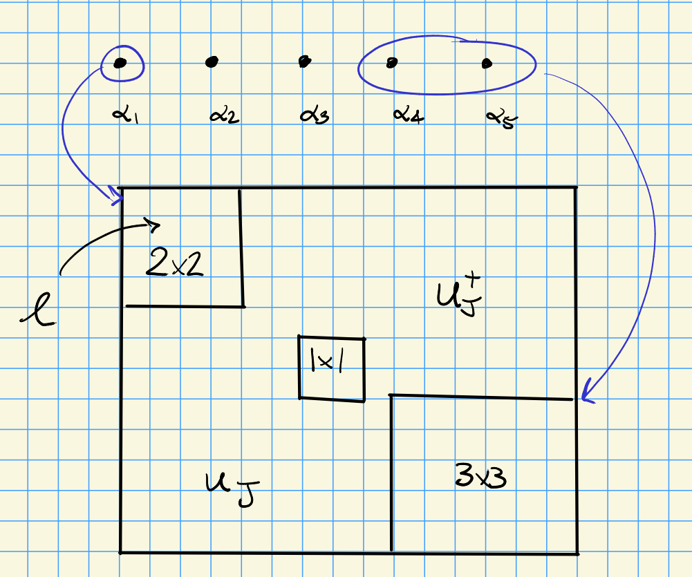

Consider induced/costandard modules $H^0( \lambda) = \operatorname{Ind}_B^G \lambda = \nabla(\lambda)$, which are nonzero only when $\lambda \in X_+$ is a dominant weight. Their characters are given by Weyl’s character formula, and their duals are essentially *Weyl modules* which admit Weyl filtrations. What are their support varieties?

Let $\lambda\in X_+$ and let $p$ be a good prime, and let $w\in W$ such that $w(\Phi_\lambda ) = \Phi_J$ for $J \subseteq \Delta$. Then
$$\begin{align*}
V_{{\mathfrak{g}}} H^0( \lambda) = G\cdot u_J = \mkern 1.5mu\overline{\mkern-1.5mu{\mathcal{O}}\mkern-1.5mu}\mkern 1.5mu
\end{align*}
is the closure of a “Richardson orbit.”$$

- This theorem was conjectured by Jantzen in 87, proved for type $A$.
- For bad primes, $H^0(\lambda)$ is computed in one of seven VIGRE papers (2007). These still yield orbit closures that are irreducible, but need not be Richardson orbits.

Natural progression: what about tilting modules (good filtrations with costandard sections and good + Weyl filtrations)? We’re aiming for the Humphreys conjecture.

Let $T( \lambda)$ be a tilting module for $\lambda \in X_+$. A conjecture of Humphreys: $V_{{\mathfrak{g}}} T( \lambda)$ arises from considering 2-sided cells of the affine Weyl group, which biject with nilpotent orbits.

In type $A_2$:

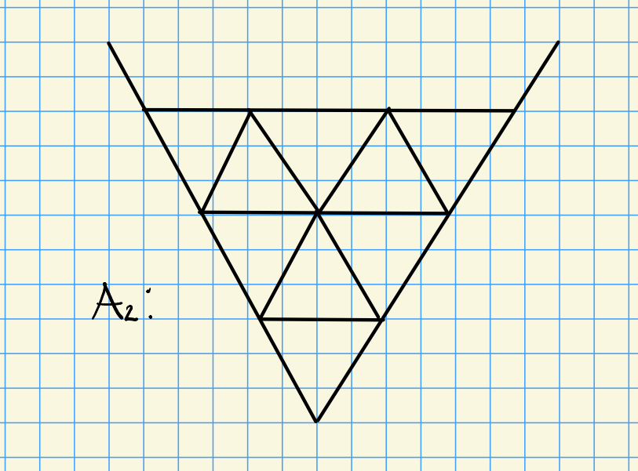

There are three nilpotent orbits corresponding to Jordan blocks of type $X\alpha_1: (1,0)$ and $X_\mathrm{reg}: (1,1)$ in ${\mathfrak{gl}}_3$. Three cases:

- $V_{{\mathfrak{g}}} T( \lambda) = {\mathcal{N}}= \mkern 1.5mu\overline{\mkern-1.5muG X_\mathrm{reg}\mkern-1.5mu}\mkern 1.5mu$
- $V_{{\mathfrak{g}}} T( \lambda) = \mkern 1.5mu\overline{\mkern-1.5muG X_{ \alpha_1}\mkern-1.5mu}\mkern 1.5mu$
- $V_{{\mathfrak{g}}} T( \lambda) = \left\{{0}\right\}$

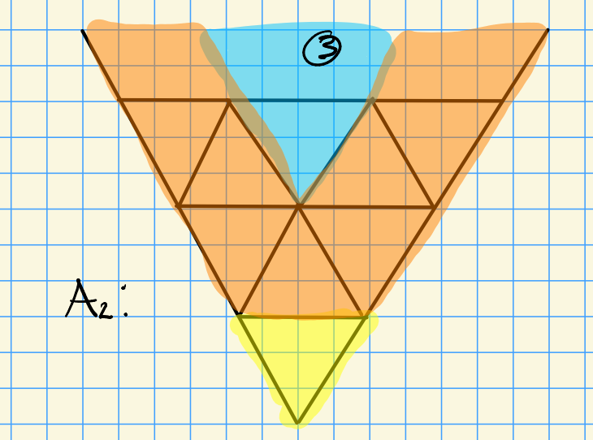

The computation of $V_G T( \lambda)$ is still open. Some recent work:

- $p=2, A_n$: done by B. Cooper,
- $p > n+1, A_n$ by W. Hardesty,
- $p \gg 1$, Achar, Hardesty, Riche.

What about simple $G{\hbox{-}}$modules? Recall $L(\lambda) = \mathop{\mathrm{Soc}}_G \nabla( \lambda) \subseteq \nabla( \lambda)$ – computing $V_G L( \lambda)$ is open.

Let $p > h$ and $w( \Phi_ \lambda) = \Phi_J$, then
$$\begin{align*}
V_{u_q({\mathfrak{g}})} L( \lambda) = G u_J
,\end{align*}
i.e. the support varieties in the quantum case are known. This uses that the Lusztig character formula is know for \(u_q( {\mathfrak{g}})\).$$

# 18 Tuesday, April 12

## 18.1 Tensor triangular geometry

Last time: tensor categories and triangulated categories. Idea due to Balmer: treat categories like rings.

A **tensor triangulated category** (TTC) is a triple $(K, \otimes, 1)$ where

- $K$ is a triangulated category
- $(K, \otimes)$ is a symmetric monoidal category
- $1$ is a unit, so $X\otimes 1 { \, \xrightarrow{\sim}\, }X { \, \xrightarrow{\sim}\, }1\otimes X$ for all $X$ in $K$.

We’ll have notions of ideals, thick ideals, and prime ideals in $K$. Define $\operatorname{Spc}K$ to be the set of prime ideals with the following topology: for a collection $C \subseteq \operatorname{Spec}K$, define $Z(C) = \left\{{p\in \operatorname{Spc}K {~\mathrel{\Big\vert}~}C \cap p = \emptyset}\right\}$. Note that there is a universal categorical construction of $\operatorname{Spc}K$ which we won’t discuss here.

TTC philosophy: let $K$ be a compactly generated TTC with a generating set $K^c$. Note that $K$ can include “infinitely generated” objects, while $K^c$ should thought of as “finite-dimensional” objects. Problems:

- What is the homeomorphism type of $\operatorname{Spc}K^c$?
- What are the thick ideals in $K^c$?

Although not all objects can be classified, there is a classification of thick tensor ideals. Idea: use the algebraic topology philosophy of passing to infinitely generated objects to simplify classification.

We’ll need a candidate space $X\cong_{\mathsf{Top}}\operatorname{Spc}(K^c)$, e.g. a Zariski space: Noetherian, and every irreducible contains a generic point. We’ll also need an assignment $V: K^c\leadsto X_{{ \operatorname{cl}} }$ (the closed sets of $X$) satisfying certain properties, which is called a *support datum*. For $I$ a thick tensor ideal, define \begin{align*} \Gamma(I) \mathrel{\vcenter{:}}=\displaystyle\bigcup_{M\in I} V(M) \in X_{\mathrm{sp}} ,\end{align*} a union of closed sets which is called *specialization closed*. Conversely, for $W$ a specialized closed set, define a thick tensor ideal
$$\begin{align*}
\Theta(W) \mathrel{\vcenter{:}}=\left\{{M\in K^c {~\mathrel{\Big\vert}~}V(M) \subseteq W}\right\}
.\end{align*}$$

One can check that a tensor product property holds: if $M\in K^c$ and $N\in \Theta(W)$, check $V(M\otimes N) = V(M) \cap V(N) \subseteq W$. Under suitable conditions, a deep result is that $\Gamma \circ \Theta = \operatorname{id}$ and $\Theta \circ \Gamma = \operatorname{id}$. This yields a bijection
$$\begin{align*}
\left\{{\substack{
\text{Thick tensor ideals of } K^c
}}\right\}
&\rightleftharpoons
\left\{{\substack{
\text{Specialization closed sets of } X
}}\right\} \\
I &\mapsto \Gamma(I) \\
\Theta(W) &\mapsfrom W
\end{align*}$$

Define
$$\begin{align*}
f: X\to \operatorname{Spc}K^c \\
x &\mapsto P_x \mathrel{\vcenter{:}}=\left\{{M \in K^c {~\mathrel{\Big\vert}~}x\not\int V(M)}\right\}
.\end{align*}
This is a prime ideal: if \(M\otimes N\in P_x\), then \(x\not \in V(M\otimes N) = V(M) \cap V(N)\), so \(M\in P_x\) or \(N\in P_x\).$$

## 18.2 Zariski spaces

A space $X\in {\mathsf{Top}}$ is a **Zariski space** iff

1. $X$ is a Noetherian space, and
2. Every irreducible closed set has a unique generic point.

Note that since $X$ is Noetherian, it admits a decomposition into irreducible components $X = \displaystyle\bigcup_{1\leq i \leq t} W_i$.

The basic examples:

- For $R$ a unital Noetherian commutative ring, $X = \operatorname{Spec}R$ is Zariski.
- For $R$ a graded unital Noetherian ring, taking homogeneous prime ideals $\mathop{\mathrm{Proj}}R$.
- For $G\in {\mathsf{Aff}}{\mathsf{Alg}}{\mathsf{Grp}}$ with $G\curvearrowright R$ a graded ring by automorphisms (permuting the graded pieces), the stack $X \mathrel{\vcenter{:}}=\mathop{\mathrm{Proj}}_G(R)$ (which is not Proj of the fixed points) is the set of $G{\hbox{-}}$invariant homogeneous prime ideals. There’s a map $\rho: \mathop{\mathrm{Proj}}R\to \mathop{\mathrm{Proj}}_G R$ where $P\mapsto \cap_{g\in G} gP$ which gives $\mathop{\mathrm{Proj}}_G R$ the quotient topology: $W\in \mathop{\mathrm{Proj}}_G R$ is closed iff $\rho\in R$ is close din $\mathop{\mathrm{Proj}}R$. This topologizes orbit closures.

Notation:

- ${\mathcal{X}}= 2^X$ for the powerset of $X$,
- ${\mathcal{X}}_{{ \operatorname{cl}} }$ the closed sets,
- ${\mathcal{X}}_{{\mathrm{irr}}}$ the irreducible closed sets,
- ${\mathcal{X}}_{\mathrm{sp} }$ the specialization-closed sets.

## 18.3 Support data

Recall

- $M = {\mathsf{kG}{\hbox{-}}\mathsf{Mod}}$
- $R = H^{\text{even}}(G; k)$
- $V_G(M) = \left\{{p\in \mathop{\mathrm{Proj}}R {~\mathrel{\Big\vert}~}\operatorname{Ext} _{kG}(M, M)_p\neq 0 }\right\}$.

A **support datum** is an assignment $V: K \to {\mathcal{X}}$ such that

1. $V(0) = \emptyset$ and $V(1) = X$.
2. $V\qty{\bigoplus _{i\in I} M_i = \displaystyle\bigcup_{i\in I} V(M_i) }$
3. $V(\Sigma M) = V(M)$ (similar to $\Omega$)
4. For any distinguished triangle $M\to N\to Q\to \Sigma M, V(N) \subseteq V(M) \cup V(Q)$.
5. $V(M\otimes N) = V(M) \cap V(N)$.

We’ll need two more properties for the Balmer classification:

6. Faithfulness: $V(M) = \emptyset \iff M \cong 0$.
7. Realization: for any $W\in {\mathcal{X}}_{{ \operatorname{cl}} }$ there exists a compact $M\in K^c$ with $V(M) = W$.

Note that (6) holds for group cohomology, and (7) is Carlson’s realization theorem.

Let $K$ be a TTC which is closed under set-indexed coproducts and let $V:K\to {\mathcal{X}}$ be a support datum. Let $C$ be a collection of objects in $K$ and suppose $W \subseteq X$ with $V(M) \subseteq W$ for all $M\in C$. Then $V(M) \subseteq W$ for all $M$ in $\mathsf{Loc}(C)$.

Note that $\mathsf{Loc}(C)$ is closed under

- Applying $\Sigma$ or $\Sigma^{-1}$,
- 2-out-of-3: if two objects in a distinguished triangle are in $\mathsf{Loc}(C)$, the third is in $\mathsf{Loc}(C)$,
- Taking direct summands,
- Taking set-indexed coproducts.

These follow directly from the properties of support data and properties of $\mathsf{Loc}(C)$.

## 18.4 Extension of support data

Let $X$ be a Zariski space and let $K\supseteq K^c$ be a compactly generated TTC. Let $V: K^c\to {\mathcal{X}}_{{ \operatorname{cl}} }$ be a support data on compact objects, we then seek an *extension*: a support datum ${\mathcal{V}}$ on $K$ forming a commutative diagram:

[figure not shown]

> Link to Diagram

Let $K$ be a compactly generated TTC and $V: K^c\to {\mathcal{X}}_{{ \operatorname{cl}} }$ be a support datum. Then ${\mathcal{V}}: K\to {\mathcal{X}}$ **extends** $V$ iff

- ${\mathcal{V}}$ satisfies properties (1) – (5) above,
- $V(M) = {\mathcal{V}}(M)$for any $M\in K^c$.
- If $V$ is faithful then ${\mathcal{V}}$ is faithful.

We’ll need Hopkins’ theorem to analyze such extensions.

# 19 Tuesday, April 19

## 19.1 Hopkins’ Theorem

Let $\mathsf{K}$ be a compactly generated tensor triangulated category with $\mathsf{K}^c$ a subcategory of compact objects. Goal: classify $\operatorname{Spc}\mathsf{K}^c$. A candidate for its homeomorphism type: we’ll build a Zariski space $X$ and a homeomorphism $\operatorname{Spc}\mathsf{K}^c \to X$. We’ll use support data $\mathbf{V}: \mathsf{K}^c\to {\mathcal{X}}_{{ \operatorname{cl}} }$ which satisfies the faithfulness and realization properties. We’ll extend this to $\mathcal{V}: \mathsf{K} \to {\mathcal{X}}$. So we need

- A Zariski space $X$,
- Support data $\mathbf V$,
- An extension ${\mathcal{V}}$.

## 19.2 Localization functors

Let $\mathsf{C} \leq \mathsf{K}$ be a thick subcategory for $\mathsf{K}\in {\mathsf{triang}}\mathsf{Cat}$. A mysterious sequence:
$$\begin{align*}
\Gamma_c(M) \to M \to L_c(M)
.\end{align*}$$

Suppose $W\in {\mathcal{X}}_{{\mathrm{irr}}}$ is nonempty and let $Z = \left\{{x\in X{~\mathrel{\Big\vert}~}w\not\subseteq { \operatorname{cl}} _X\left\{{x}\right\}}\right\}$. Define a functor $\nabla_W = \Gamma_{I_W} L_{I_Z}$ and ${\mathcal{V}}(M) \mathrel{\vcenter{:}}=\left\{{x\in X {~\mathrel{\Big\vert}~}\nabla_{\left\{{x}\right\}} (M) = 0}\right\}$.

Let $\mathsf{K}$ be a compactly generated tensor triangulated category, $X$ a Zariski space, and ${\mathcal{X}}_{{ \operatorname{cl}} }$ the closed sets. Given a compact object $M\in \mathsf{K}^c$, let $\left\langle{M}\right\rangle_{\mathsf{K} ^c}$ be the thick tensor ideal in $\mathsf{K}^c$ generated by $M$. Let $\mathbf V: \mathsf{K}^c\to {\mathcal{X}}_{{ \operatorname{cl}} }$ be support data satisfying the faithfulness condition and suppose ${\mathcal{V}}: \mathsf{K}\to {\mathcal{X}}$ is an extension. Set $W = \mathbf V(M)$ and $I_W = \left\{{N\in \mathsf{K}^c {~\mathrel{\Big\vert}~}V(N) \subseteq W}\right\}$. Then
$$\begin{align*}
I_W = \left\langle{M}\right\rangle_{\mathsf{K}^c}
,\end{align*}
i.e. this is generated by a single object.$$

Let $I \mathrel{\vcenter{:}}= I_W$ and $I' \mathrel{\vcenter{:}}=\left\langle{M}\right\rangle_{\mathsf{K}^c}$.

$I' \subseteq I$: If $N\in I'$, then $N$ is obtained by taking direct sums, direct summands, distinguished triangles, shifts, etc. These all preserve support containment, so $\mathbf V(N) \subseteq W$ and $N\in I = I_W$.

$I \subseteq I'$: Let $N\in {\mathsf{K^c}}$. Apply the functorial triangle $\Gamma_{I'} \to \operatorname{id}\to L_{I'}$ to $\Gamma_I(N)$ to obtain
$$\begin{align*}
\Gamma_{I'} \Gamma_I N\to \Gamma_I(N) \to L_{I'} \Gamma_I N
.\end{align*}
From above, \(I' \subseteq I\) so the first term is in \(\mathsf{Loc}(I)\). Since the second term is as well, the 2-out-of-3 property guarantees that the third term satisfies \(L_{I'} \Gamma_I N \in\mathsf{Loc}(I)\). By the lemma, \(V(L_{I'} \Gamma_I N) \subseteq W\). There are no nonzero maps \(I' \to VL_{I'}\Gamma_I N\), therefore for \(S\in {\mathsf{K^c}}\), noting that \(S\otimes M \in I'\),
\begin{align*}
0
= \mathop{\mathrm{Hom}}_{\mathsf{K}}(S\otimes M, L_{I'} \Gamma_I M)
= \mathop{\mathrm{Hom}}_{\mathsf{K}}(S, M {}^{ \vee }\otimes L_{I'} \Gamma_I N)
,\end{align*}
and since \(S\) is an arbitrary compact object, this forces \(M {}^{ \vee }\otimes L_{I'} \Gamma_I N = 0\). By faithfulness, and the tensor product property,
\begin{align*}
\emptyset
&= {\mathcal{V}}(M {}^{ \vee }\otimes L_{I'} \Gamma_I N)\\
&= {\mathcal{V}}(M {}^{ \vee }) \cap{\mathcal{V}}(L_{I'}\Gamma_I N)\\
&= \mathbf{V}(M) \cap{\mathcal{V}}(L_{I'} \Gamma_I N)\\
&= W \cap{\mathcal{V}}(L_{I'} \Gamma_I N)\\
&= {\mathcal{V}}(L_{I'} \Gamma_I N)
,\end{align*}
so by faithfulness (again) \(L_{I'} \Gamma_I N = 0\). Thus by the localization triangle, \(\Gamma_{I'} \Gamma_I N \cong \Gamma_I N\).$$

Now specialize to $N\in I$; the localization triangle yields
$$\begin{align*}
\Gamma_I N \to N \xrightarrow{0} L_I(N) \implies \Gamma_I N \cong N
.\end{align*}
Now replacing \(I\) with \(I'\) yields \(\Gamma_{I'} N \cong N\) since \(L_{I'} N \cong L_{I'} \Gamma_I N \cong 0\) by the previous part. Thus \(N\in \mathsf{Loc}(I')\) by applying a result of Neeman, implying \(N\in I'\) and \(I \subseteq I'\).$$

Many different takes on classification of thick tensor ideals:

- Benson, Carlson, Rickard at UGA in the late 90s, for finite group representations (now extended).
- Benson, Iyengar, Krause: axiomatic approach and description of supports.
- Dell’Ambrogio
- Boe, Kujawa, Nakano

Let

- $\mathsf{K}$ be a compactly generated tensor triangulated category,
- $X$ be a Zariski space,
- $\mathbf{V}: {\mathsf{K^c}}\to {\mathcal{X}}_{{ \operatorname{cl}} }$ be a support datum satisfying both the faithfulness *and* realization properties,
- ${\mathcal{V}}: \mathsf{K}\to C$ be an extension of $\mathbf{V}$.

Let $\operatorname{Id}({\mathsf{K^c}})$ be the set of thick tensor ideals in ${\mathsf{K^c}}$, then there is a bijection

$$\begin{align*}
\operatorname{Id}({\mathsf{K^c}})
&\rightleftharpoons
{\mathcal{X}}_{\mathrm{sp} } \\
I &\mapsto \Gamma(I) \mathrel{\vcenter{:}}=\displaystyle\bigcup_{M\in I} \mathbf{V}(I) \\
\Theta(W) = I_W \mathrel{\vcenter{:}}=\left\{{N\in {\mathsf{K^c}}{~\mathrel{\Big\vert}~}\mathbf V(N) \subseteq W}\right\} &\mapsfrom W
.\end{align*}$$

Show that $I_W\in \operatorname{Id}({\mathsf{K^c}})$ is in fact a thick tensor ideal.

$\Gamma \circ \Theta = \operatorname{id}$: Check that
$$\begin{align*}
\Gamma\Theta W = \Gamma(I_W) = \displaystyle\bigcup_{M\in I_W} \mathbf{V}(M) \subseteq W
.\end{align*}
For the reverse inclusion, let \(W = \displaystyle\bigcup_{j\in W} W_j\) where \(W_j\in {\mathcal{X}}_{{ \operatorname{cl}} }\). By the realization property, there exist \(N_j \in {\mathsf{K^c}}\) such that \(\mathbf{V}(N_j) = W_j\), so \(N_j\in I_W\). Now \(W \subseteq \displaystyle\bigcup_{M\in I_W} \mathbf{V}(M)\), so \(W = \displaystyle\bigcup_{M\in I_W} \mathbf{V}(M)\).$$

$\Theta \circ \Gamma = \operatorname{id}$: For $I\in \operatorname{Id}({\mathsf{K^c}})$, set $W \mathrel{\vcenter{:}}=\Gamma(I) = \displaystyle\bigcup_{M\in I} \mathbf{V}(M)$, then
$$\begin{align*}
\Theta\Gamma I = \Theta(W) = I_W \supseteq I
.\end{align*}
For the reverse inclusion \(I_W \subseteq I\): let \(N\in I_W\). Since \(X\) is a Zariski space, \(X\) is Noetherian and there is an irreducible component decomposition \(V(N) = \displaystyle\bigcup_i W_i\) with each \(W_i\) irreducible with a unique generic point, so \(W_i = { \operatorname{cl}} _{W_i} \left\{{x_i}\right\}\). Since each \(W_i \subseteq W\), each \(x_i\in W = \displaystyle\bigcup\mathbf{V}(M)\), so there exist \(M_i\) with \(x_i \in \mathbf{V}(M_i)\). Since supports are closed, \(W_i = { \operatorname{cl}} _{W_i}\left\{{x_i}\right\} \subseteq \mathbf{V}(M_i)\). Setting \(M\mathrel{\vcenter{:}}=\bigoplus _i M_i\in I\) yields \(V(N) \subseteq \displaystyle\bigcup V(M_i) = V(M) \subseteq W\).$$

$$\begin{align*}
N \in \left\langle{M}\right\rangle_{{\mathsf{K^c}}}
.\end{align*}$$

Proving the claim will complete the proof, since $I$ is a thick ideal containing $M$, so $\left\langle{M}\right\rangle_{{\mathsf{K^c}}} \subseteq I$ and $N\in I$.

By Hopkins’ theorem, $\left\langle{M}\right\rangle_{{\mathsf{K^c}}} = I_Z$ where $Z = \mathbf{V}(M)$. Since $V(N) \subseteq V(M) = Z$, we have $N\in I_Z = \left\langle{M}\right\rangle_{{\mathsf{K^c}}}$.

Next time:

- Showing $\operatorname{Spc}{\mathsf{K^c}}\underset{{\mathsf{Top}}}{\cong} X$
- Examples: ${\mathsf{kG}{\hbox{-}}\mathsf{stMod}}$, ${\mathsf{u({\mathfrak{g}})}{\hbox{-}}\mathsf{stMod}}$, and ${\mathbb{D}}{\mathsf{R}{\hbox{-}}\mathsf{Mod}}$.

# 20 Thursday, April 21

## 20.1 Classification theorem

Let $\mathsf{K}$ be a compactly generated tensor-triangulated category and let $X$ be a Zariski space. Suppose that

1. $\mathbf{V}: \mathsf{K}^c\to {\mathcal{X}}_{{ \operatorname{cl}} }$ is a support datum,
2. $\mathbf{V}$ satisfies the faithfulness property,
3. ${\mathcal{V}}: \mathsf{K}\to {\mathcal{X}}$ extends $\mathbf{V}$.

Then there exists a bijective correspondence
$$\begin{align*}
\adjunction{\Gamma}{\Theta}{\operatorname{Id}(\mathsf{K}^c) }{{\mathcal{X}}_{\mathrm{sp}} }
\end{align*}
where \(\Gamma(I) \mathrel{\vcenter{:}}=\displaystyle\bigcup_{M\in I} \mathbf{V}(M)\) and \(\Theta(W) \mathrel{\vcenter{:}}=\left\{{N\in\mathsf{K}^c{~\mathrel{\Big\vert}~}\mathbf{V}(N) \subseteq W}\right\}\).$$

This relies on Hopkins’ theorem.

## 20.2 Balmer spectrum

Let $\mathsf{K}$ and $X$ be as in the previous theorem, satisfying the same assumptions. Then there exists a homeomorphism $f: X\to \operatorname{Spc}\mathsf{K}^c$.

Since $\mathbf{V}: \mathsf{K}^c\to {\mathcal{X}}_{{ \operatorname{cl}} }$ is a support datum, Balmer shows there exists a continuous map
$$\begin{align*}
f: X &\to \operatorname{Spc}\mathsf{K}^c \\
x &\mapsto P_x \mathrel{\vcenter{:}}=\left\{{M{~\mathrel{\Big\vert}~}x\not\in\mathbf{V}(M) }\right\}
.\end{align*}$$

Note that $P_x$ is a prime ideal:

$$\begin{align*}
M\otimes N\in P_x
&\implies x\not\in\mathbf{V}(M\otimes N) \\
&\implies x\not\in\mathbf{V}(M) \cap\mathbf{V}(N) \\
&\implies x\not\in \mathbf{V}(M) \text{ or } x\not\in \mathbf{V}(N) \\
&\implies M\in P_x \text{ or } N\in P_x
.\end{align*}$$

Applying the classification theorem, this yields a bijection.

Examples of classification:

To prove these properties, Benson-Carlson-Rickard start with $E$ elementary abelian, so $E = \left\langle{x_1,\cdots, x_n}\right\rangle \cong C_p{ {}^{ \scriptscriptstyle\times^{n} } }$ with $o(x_i) = p$ for all $i$. Set $y_i = x_i-1 \in kE$, so $y_i^p=0$, and define cyclic subgroups $\mathbf{\alpha }= {\left[ {\alpha_1,\cdots, \alpha_n} \right]} \in L^n$ where $L/k$ is a field of large transcendence degree. Define $y_{\mathbf{\alpha}} \mathrel{\vcenter{:}}=\sum_{1\leq i\leq n} \alpha_i y_i$ and define a rank variety
$$\begin{align*}
{\mathcal{V}}_E^r(M) = \left\{{ \mathbf{\alpha }\in L^n {~\mathrel{\Big\vert}~}L\otimes_k M \downarrow_{\left\langle{y_{\mathbf{\alpha}}}\right\rangle} \text{ is not free } }\right\}\cup\left\{{0}\right\}
.\end{align*}$$

Let $E$ be as above and suppose $\operatorname{trdeg}(L/k) \geq n$. Then if $M\in \mathsf{K}$, ${\mathcal{V}}_E(M) \cong {\mathcal{V}}_E^r(M)$, and the three properties for (3) above hold for $E$.

Let $A = kG$ for $G$ a finite group scheme, and let $R = H^{\mathrm{even}}(G; k)$ and $X = \mathop{\mathrm{Proj}}(R)$. Then

- There is a bijective correspondence
  $$\begin{align*}
  \adjunction{\Gamma}{\Theta}{{\mathsf{kG}{\hbox{-}}\mathsf{stMod}}}{{\mathcal{X}}_{\mathrm{sp}}}
  .\end{align*}$$
- $\operatorname{Spc}({\mathsf{kG}{\hbox{-}}\mathsf{stMod}}) \underset{{\mathsf{Top}}}{\cong} X$.

Some remarks:

- This theorem is an indication of why cohomology is central in understanding the tensor structure of representation categories. If $G\in {\mathsf{Fin}}{\mathsf{Grp}}{\mathsf{Sch}}_{/ {k}}$ then the coordinate ring $k[G]$ is a commutative Hopf algebra, so $A = kG = k[G] {}^{ \vee }$ is a finite dimensional cocommutative Hopf algebra. So there is an equivalence of categories between ${\mathsf{Rep}}G$ and ${\mathsf{Rep}}A$ for $A$ such a Hopf algebra. By a result of Friedlander-Suslin, $R$ is finitely generated.
- The realization of $\mathbf{V}$ and ${\mathcal{V}}$ for a general group scheme involve so-called *$\pi{\hbox{-}}$points* developed be Friedlander-Pevtsovz and the construction of explicit rank varieties.

A special case: let ${\mathfrak{g}}= \mathsf{Lie}G$ for $G\in{\mathsf{Alg}}{\mathsf{Grp}}_{/ {k}}$ reductive and $k$ positive characteristic. Let $A = u({\mathfrak{g}})$, which is a finite-dimensional cocommutative Hopf algebra. If $p > h$ for $h$ the Coxeter number,
$$\begin{align*}
{\mathcal{N}}_p = \left\{{x\in {\mathfrak{g}}{~\mathrel{\Big\vert}~}x^{[p]} = 0 }\right\} = {\mathcal{N}}, \text{ the nilpotent cone}
,\end{align*}
\(R = H^{\mathrm{even}}(u({\mathfrak{g}}); k) = k[{\mathcal{N}}]\), and \(X = \mathop{\mathrm{Proj}}(k[{\mathcal{N}}])\), then applying the theorem,$$

- There is a correspondence
  $$\begin{align*}
  \adjunction{}{}{{\mathsf{u({\mathfrak{g}})}{\hbox{-}}\mathsf{stMod}}}{{\mathcal{X}}_{\mathrm{sp}}}
  .\end{align*}$$
- There is a homeomorphism
  $$\begin{align*}
  \operatorname{Spc}\qty{ {\mathsf{u({\mathfrak{g}})}{\hbox{-}}\mathsf{stMod}} } \underset{{\mathsf{Top}}}{\cong} \mathop{\mathrm{Proj}}(k[{\mathcal{N}}])
  .\end{align*}$$

Let $\tilde {\mathcal{N}}\to {\mathcal{N}}$ be the Springer resolution. There is an equivalence of derived categories
$$\begin{align*}
{\mathbb{D}}^b {\mathsf{ u_\zeta({\mathfrak{g}})_0}{\hbox{-}}\mathsf{Mod}} { \, \xrightarrow{\sim}\, }{\mathbb{D}}^b {\mathsf{Coh}}^{G\times {\mathbb{C}}^{\times}} k[\tilde{\mathcal{N}}] { \, \xrightarrow{\sim}\, }{\mathbb{D}}^b \mathsf{Perv}({\Omega}{\operatorname{Gr}})
.\end{align*}
where \(\mathsf{Perv}({-})\) is the category of perverse sheaves and \({\Omega}{\operatorname{Gr}}\) is the loop Grassmannian.$$

For $M$ a $u_\zeta({\mathfrak{g}}){\hbox{-}}$module and $R = H^{\mathrm{even}}(u_\zeta({\mathfrak{g}}); M) = {\mathbb{C}}[{\mathcal{N}}] \cong {\mathbb{C}}[\tilde {\mathcal{N}}]$. There is an action of $R$ on ${ {H}^{\scriptscriptstyle \bullet}} (u_\zeta({\mathfrak{g}}); M)$. Next time: examples for Lie superalgebras and Thomason’s reconstruction theorem for rings.

# 21 Tuesday, April 26

> See Boe-Kujawa-Nakano, Adv. Math 2017.

Setup: $\mathsf{K}^c \leq \mathsf{K}\in {\mathsf{TTC}}$, $X$ a Zariski space, $V:\mathsf{K}^c\to {\mathcal{X}}_{{ \operatorname{cl}} }$ with an extension ${\mathcal{V}}:\mathsf{K}\to {\mathcal{X}}$. Let ${\mathfrak{g}}= {\mathfrak{g}}_{0} \oplus {\mathfrak{g}}_1$ be a Lie superalgebra with a $C_2$ grading over $k= {\mathbb{C}}$ where ${\mathfrak{g}}_0\curvearrowright{\mathfrak{g}}_1$, e.g. ${\mathfrak{gl}}_{m, n} = {\mathfrak{gl}}_m \times {\mathfrak{gl}}_n$ with matrices ${ \begin{bmatrix} {{\mathfrak{g}}_0} & {{\mathfrak{g}}_1} \\ {{\mathfrak{g}}_1} & {{\mathfrak{g}}_0} \end{bmatrix} }$ with the bracket action. Write $\mathsf{Lie}G_0 = {\mathfrak{g}}_0$, and note that $G_0$ is reductive. Let ${\mathcal{F}}({\mathfrak{g}}, {\mathfrak{g}}_0)$ be the category of finite-dimensional ${\mathfrak{g}}{\hbox{-}}$supermodules which are completely reducible over ${\mathfrak{g}}_0$. Take $\mathsf{K}^c = {\mathsf{{\mathcal{F}}({\mathfrak{g}},{\mathfrak{g}}_0)}{\hbox{-}}\mathsf{stMod}} \leq \mathsf{K} = {\mathsf{C({\mathfrak{g}}, {\mathfrak{g}}_0)}{\hbox{-}}\mathsf{stMod}}$, where for $C$ we drop the finite-dimensional condition.

Set $R = H^0({\mathfrak{g}}_1, {\mathfrak{g}}_0; {\mathbb{C}}) = \operatorname{Ext} ({\mathbb{C}},{\mathbb{C}}) \cong S({\mathfrak{g}}_0 {}^{ \vee })^{G_0}$. By a theorem of Hilbert, $\operatorname{Ext} (M, M)$ is finitely generated over $R$. Write $V_{{\mathfrak{g}},{\mathfrak{g}}_0}(M) = \mathrm{sp}ec R/J_M$ – for Kac modules $K(\lambda) = U({\mathfrak{g}}) \otimes_{U(P^0)} L_0(\lambda)$, $V = 0$ but not every $K(\lambda)$ is projective.

Idea: use detecting subalgebras. For ${\mathfrak{g}}= {\mathfrak{gl}}_{n,n}$, let $f_1$ be the “torus”:

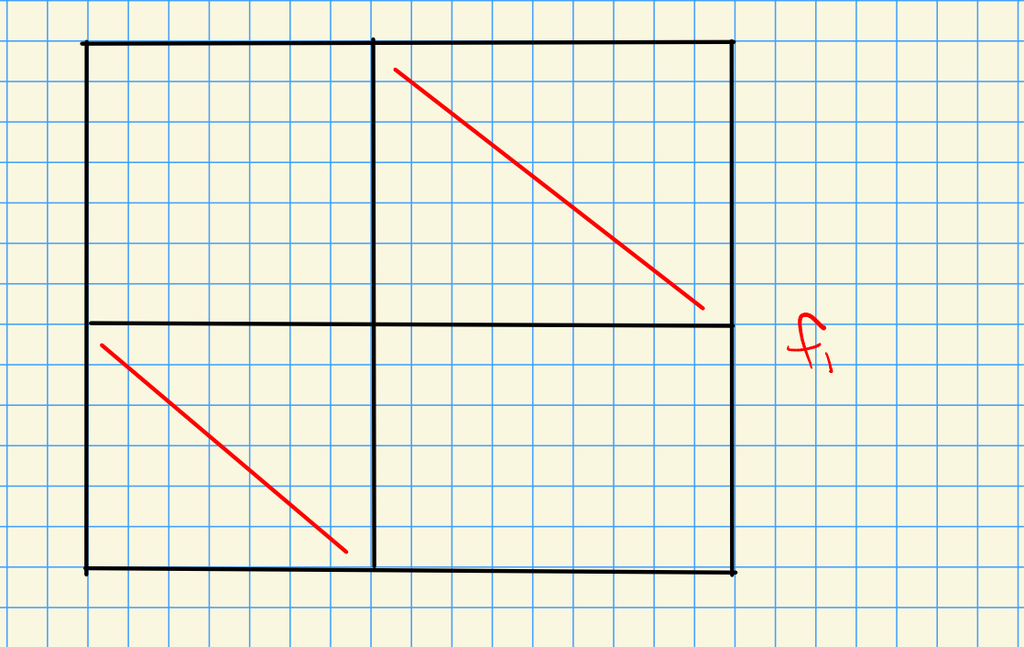

Then define $f_0 = [f_1, f_1]$.

Let $X = N\mathop{\mathrm{Proj}}(S^*(f_1 {}^{ \vee }))$ where $S^*(f_1 {}^{ \vee }) \cong \operatorname{Ext} _{f_1, f_0}({\mathbb{C}}, {\mathbb{C}}) = R'$ and $N = { N }_{G_0}(f_1)$, which is a reductive algebraic group. Define a support datum by $\mathbf{V}(M) = \left\{{p\in X{~\mathrel{\Big\vert}~}\operatorname{Ext} _{f, f_0}(M,M)_p = 0}\right\}$. The goal is to construct ${\mathcal{V}}: K\to {\mathcal{X}}$ using localization functors – one needs to show the tensor product formula, and the faithfulness and realization properties, which follows from Dede’s lemma. It turns out that $f_1\cong {\mathfrak{sl}}(1,1){ {}^{ \scriptscriptstyle\times^{m} } }$ and it suffices to define the rank variety on $f_1$. Define
$$\begin{align*}
V_{f_1}^{\operatorname{rank}}(M) = \left\{{\mkern 1.5mu\overline{\mkern-1.5mux\mkern-1.5mu}\mkern 1.5mu = \tilde K\otimes_{\mathbb{Q}}f_1 {~\mathrel{\Big\vert}~}K\otimes_{\mathbb{C}}M\downarrow{\left\langle{\mkern 1.5mu\overline{\mkern-1.5mux\mkern-1.5mu}\mkern 1.5mu}\right\rangle} \text{ is not projective} }\right\}
\end{align*}
where \(\tilde K\supseteq{\mathbb{C}}\) is an extension with \(\operatorname{trdeg}_{\mathbb{C}}\tilde K \geq \dim f_1\). A theorem shows \({\mathcal{V}}(M) = V_{f_1}^{\operatorname{rank}}(M)\) for \(M\in K\). This yields a classification for \({\mathfrak{gl}}_{m, n}\) of thick tensor ideals in \(K^c\) in terms of \({\mathcal{X}}_{\mathrm{sp}}\).$$

What is the classification of other Lie superalgebras? This is an open problem.

## 21.1 Noncommutative theory

How does one extend this theory to noncommutative TTCs? See Nakano-Vashaw-Yakomov, to appear in Amer J. Math.

Let $K$ be a compactly generated monoidal triangulated category, not necessarily symmetric. One approaches this via noncommutative ring theory, where e.g. even the definition of prime ideals differs. We’ll only consider 2-sided ideals.

A thick triangulated subcategory $P$ is a **completely prime** ideal iff $M\otimes N\in P\implies M\in P$ or $N\in P$. The ideal $P$ is **prime** iff $I\otimes J\subseteq P \implies I \subseteq P$ or $J \subseteq P$, where $I,J$ are themselves ideals. Define $\mathrm{sp}c K$ to be prime ideals and $\mathrm{CP}\operatorname{Spc}K$ to be completely prime ideals.

Let $A\in \mathsf{Hopf}{\mathsf{Alg}_{/k} }^{{\mathrm{fd}}}$ where the coproduct $\Delta: A\to A{ {}^{ \scriptstyle\otimes_{k}^{2} } }$ is not necessarily commutative, e.g. in the setting of quantum groups. Some remarks:

- Note that $M\otimes N \not\cong N\otimes M$ in general.
- Here $\mathrm{sp}c K^c$ is not known, but there is a conjectural answer.
- In general $\mathrm{sp}c K^c\not\cong \mathop{\mathrm{Proj}}R$ for $R = H(A; k)$.
- $R$ is not known to be finitely-generated. Etingof-Ostrik conjecture this in the setting of finite tensor categories.
- The definition of prime ideals is due to Buan-Krause-Solberg in 2007.
- A weird example: there are nilpotents where $M\neq 0$ (is not projective) but $M{ {}^{ \scriptstyle\otimes_{k}^{2} } } = 0$ (is projective).
- Being a prime ideal $P$ is equivalent to $A\otimes C\otimes B \in P$ for all $C$ $\implies A\in P$ or $B\in P$.

Let $K$ be a monoidal triangulated category, $X$ a Zariski space, and ${\mathcal{X}}= 2^X$ the subsets of $X$. A map $\sigma: K\to{\mathcal{X}}$ is a **weak support datum** iff

- $\sigma(0) = \emptyset$ and $\sigma(\one) = X$
- $\sigma(A\otimes B) = \sigma(A) \cup\sigma(B)$
- $\sigma(\Sigma A) = \sigma(A)$
- If $A\to B\to C$ is exact then $\sigma(A) \subseteq \sigma(B) \cup\sigma(C)$.

Set $\Phi_\sigma(I) \mathrel{\vcenter{:}}=\displaystyle\bigcup_{M\in I} \sigma(I)$; Then $\sigma$ is a **support datum** if additionally

- $\displaystyle\bigcup_{C\in K} \sigma(A\otimes C\otimes B)= \sigma(A) \cap\sigma(B)$ and
- $\Phi_\sigma(I\otimes J) = \Phi_\sigma(I) \cap\Phi_\sigma(J)$.

Next time:

- Classification theorems
- The NVY conjecture for finite-dimensional Hopf algebras.
- Tensor product theorems.
- Examples of applications.

# 22 Bibliography

1.

Jacobson, N.: Basic algebra II. Dover Publications, Inc. (2009)